# Diastolic blood pressure in Kenyan outpatient attenders

Dataset 4: Kenya hypertension screening survey

RSR feasibility analysis

2026-08-03

# Introduction

Diastolic blood pressure is the pressure in the arteries between beats, and in younger and middle-aged adults it is the component of blood pressure most closely tied to peripheral vascular resistance. It behaves quite differently from systolic pressure across the life course: diastolic pressure typically rises until the fifth or sixth decade and then falls as large arteries stiffen, while systolic pressure keeps rising. This dataset is a cross-sectional screening survey of 1444 adults recruited at three types of Kenyan outpatient facility - a government (public) facility, a private facility and a faith-based mission facility - in which each participant had blood pressure measured three times and completed a WHO STEPS-style questionnaire.

**Aim.** Among these Kenyan outpatient attenders, we examined which of age band, sex, education, BMI category, current smoking, current alcohol use, physical activity and self-reported diabetes are independently associated with average diastolic blood pressure, mutually adjusting for the others.

This is a *Purpose 3* analysis: several predictors are of interest and the question is which remain associated with the outcome after mutual adjustment.

# Methods

**Data source.** A cross-sectional facility-based screening survey of 1444 adults aged 18 and over attending outpatient services at three Kenyan facilities (450 public, 557 private, 437 faith-based). Blood pressure was taken three times per participant and the file carries the average of the three readings.

**Variables.** The outcome is `diastolic_bp`, the mean of three diastolic readings in mmHg, treated as continuous (observed range 44 to 135 mmHg). Predictors are age band (reference *26-35*, the largest band); sex (reference *Female*); education (reference *No School*); WHO BMI category (reference *Healthy*); current smoking (reference *No*); current alcohol use (reference *No*); meeting the physical-activity recommendation (reference *No*); and self-reported diabetes (reference *no*, with *unknown* retained as a substantive third level rather than treated as missing).

**BMI is categorical, not continuous.** The file contains only the WHO `bmi_category` label, not height, weight or a BMI value, so no per-unit BMI effect (mmHg per kg/m2) can be reported from these data. More generally **no predictor in this file is continuous** - age is supplied only as a six-level band - so this linear model is a cell-means (ANOVA-style) model and no slope-per-unit statement of any kind is possible.

**Variables deliberately excluded.** `hypertension` is defined *from* the measured average blood pressure and is therefore a deterministic function of this outcome and `systolic_bp`; it can never sit on the right-hand side. `systolic_bp` is excluded because it is the other half of the same measurement (correlation with diastolic pressure r = 0.71), a co-outcome rather than an exposure; a model containing it would explain a great deal of variance and answer nothing. `prior_htn_diagnosis` is kept out of the main model and examined separately, because a prior diagnosis usually implies treatment, which lowers measured pressure, so that variable sits downstream of the outcome as much as upstream of it. `monthly_income` is excluded on missing-data grounds and its cost is quantified below.

**Statistical analysis.** `lm()`, justified because the outcome is a continuous, roughly symmetric measurement. We fitted a univariable model for each predictor first, then a single multivariable model containing all eight. Predictors were chosen in advance on subject-matter grounds, not by significance. Significance threshold 0.05; estimates are reported with 95% confidence intervals. Assumptions were checked with `performance::check_model()`, and because non-constant variance was flagged we additionally report HC3 heteroscedasticity-consistent standard errors. Analysis used R version 4.6.0 (2026-04-24) with tidyverse, gtsummary and performance.

**Missing data.** Complete-case analysis: 1376 of 1444 rows were analysed (68 dropped, 4.7%). The outcome and four predictors are 100% complete; the losses come from `bmi_category` (31 missing), `education` (21) and `age_group` (17). The one seriously incomplete variable is `monthly_income`, missing for 453 participants (31.4%); it is not in the main model and the section *The cost of `monthly_income`* below reports what including it would do.

# Results

## Sample characteristics

**Table 1. Sample characteristics, complete-case analytic sample.**

| **Characteristic** | **N** | **N = 1,376**<sup>1</sup> |
| --- | --- | --- |
| Diastolic BP (mmHg) | 1,376 | 78 (70, 86) |
| Age band (years) | 1,376 |  |
| 26-35 |  | 287 (21%) |
| 18-25 |  | 100 (7.3%) |
| 36-45 |  | 274 (20%) |
| 46-55 |  | 256 (19%) |
| 56-65 |  | 242 (18%) |
| >65 |  | 217 (16%) |
| Sex | 1,376 |  |
| Female |  | 741 (54%) |
| Male |  | 635 (46%) |
| Education | 1,376 |  |
| No School |  | 178 (13%) |
| Primary |  | 234 (17%) |
| Secondary |  | 363 (26%) |
| Tertiary |  | 601 (44%) |
| BMI category (WHO) | 1,376 |  |
| Healthy |  | 547 (40%) |
| Underweight |  | 80 (5.8%) |
| Overweight |  | 444 (32%) |
| Obese |  | 305 (22%) |
| Current smoker | 1,376 | 89 (6.5%) |
| Current alcohol use | 1,376 | 114 (8.3%) |
| Meets activity recommendation | 1,376 | 615 (45%) |
| Self-reported diabetes | 1,376 |  |
| no |  | 937 (68%) |
| yes |  | 187 (14%) |
| unknown |  | 252 (18%) |

<sup>1</sup> Median (Q1, Q3); n (%)

Median diastolic pressure is 77.7 mmHg (IQR 70.0 to 86.0), a much tighter distribution than systolic pressure and closer to symmetric. The sample is predominantly female (54%), better educated than the Kenyan adult population (44% tertiary) and 54% overweight or obese; current smoking (6.5%) and alcohol use (8.3%) are rare, as expected in a mostly female sample.

## Exploratory figure

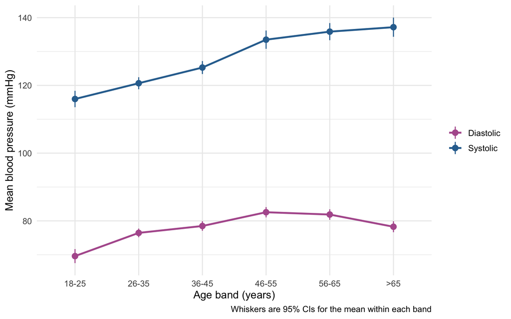

Figure 1. Mean systolic and diastolic blood pressure by age band, with 95% confidence intervals. Diastolic pressure peaks in the fifth decade and then falls; systolic pressure keeps rising.

Diastolic pressure rises from 69.6 mmHg in the 18-25 band to a peak of 82.6 mmHg at 46-55 and then falls back to 78.3 mmHg in the over-65s, while systolic pressure climbs throughout - so the age relationship for this outcome is an inverted U rather than a straight line, and pulse pressure widens from about 46 to 59 mmHg, the classic signature of large-artery stiffening.

## Univariable models

| **Characteristic** | **N** | **Beta** | **95% CI** | **p-value** |
| --- | --- | --- | --- | --- |
| Age band (years) | 1,376 |  |  |  |
| 26-35 |  | — | — |  |
| 18-25 |  | -6.5 | -9.2, -3.7 | <0.001 |
| 36-45 |  | 2.3 | 0.29, 4.3 | 0.025 |
| 46-55 |  | 6.3 | 4.2, 8.3 | <0.001 |
| 56-65 |  | 5.7 | 3.7, 7.8 | <0.001 |
| >65 |  | 2.4 | 0.26, 4.5 | 0.028 |
| Sex | 1,376 |  |  |  |
| Female |  | — | — |  |
| Male |  | 1.4 | 0.09, 2.8 | 0.036 |
| Education | 1,376 |  |  |  |
| No School |  | — | — |  |
| Primary |  | 3.3 | 0.89, 5.7 | 0.007 |
| Secondary |  | -0.67 | -2.9, 1.6 | 0.6 |
| Tertiary |  | -1.3 | -3.4, 0.79 | 0.2 |
| BMI category (WHO) | 1,376 |  |  |  |
| Healthy |  | — | — |  |
| Underweight |  | -2.8 | -5.7, 0.09 | 0.057 |
| Overweight |  | 3.5 | 2.0, 5.1 | <0.001 |
| Obese |  | 5.2 | 3.5, 7.0 | <0.001 |
| Current smoker | 1,376 |  |  |  |
| No |  | — | — |  |
| Yes |  | 2.5 | -0.21, 5.2 | 0.071 |
| Current alcohol use | 1,376 |  |  |  |
| No |  | — | — |  |
| Yes |  | 3.5 | 1.1, 5.9 | 0.005 |
| Meets activity recommendation | 1,376 |  |  |  |
| No |  | — | — |  |
| Yes |  | -0.27 | -1.6, 1.1 | 0.7 |
| Self-reported diabetes | 1,376 |  |  |  |
| no |  | — | — |  |
| yes |  | 2.0 | 0.00, 3.9 | 0.050 |
| unknown |  | 3.1 | 1.4, 4.9 | <0.001 |

Abbreviation: CI = Confidence Interval

Age is again the strongest crude predictor but the pattern is not monotonic: relative to the 26-35 band, the 46-55 band averages 6.28 mmHg (95% CI 4.24 to 8.32) higher diastolic pressure (p < 0.001) and the 56-65 band 5.74 mmHg (95% CI 3.66 to 7.81) (p < 0.001), but the over-65s only 2.39 mmHg (95% CI 0.26 to 4.52) (p = 0.028) - the coefficient falls back in the oldest band exactly as Figure 1 showed. Adiposity is the other clear crude signal: obese participants average 5.23 mmHg (95% CI 3.50 to 6.96) above healthy-weight participants (p < 0.001) and overweight participants 3.54 mmHg (95% CI 2.00 to 5.08) (p < 0.001). Current alcohol use is associated with 3.48 mmHg (95% CI 1.08 to 5.88) (p = 0.005) - a crude association it does *not* have with systolic pressure - and men average 1.42 mmHg (95% CI 0.09 to 2.75) above women (p = 0.036). Primary schooling sits 3.32 mmHg (95% CI 0.89 to 5.75) above no schooling (p = 0.007), diabetes 1.97 mmHg (95% CI 0.00 to 3.93) (p = 0.050), and physical activity shows nothing.

## Why adjustment is needed

The crude estimates cannot be compared with one another because the predictors are heavily interlocked. **Age band** confounds nearly everything, but in a way that is easy to get wrong for this outcome: it is associated with diabetes (19% of over-65s report diabetes versus 5% of 26-35s), with education (31% of over-65s never attended school versus 11% of 26-35s) and with BMI category, and it has a non-monotonic relationship with diastolic pressure. The crude diabetes coefficient of about 2.0 mmHg is therefore mostly an age and adiposity contrast between people with and without diabetes. **Sex** confounds both behavioural exposures: only 32 of the 114 current drinkers in the analytic sample are women, and 81 of 89 smokers are men, while men also have higher diastolic pressure at a given age - so the crude alcohol and smoking coefficients are partly sex coefficients and must be adjusted before they mean anything. **BMI category** confounds the diabetes and activity contrasts, since adiposity causes both insulin resistance and raised peripheral resistance. Mutual adjustment lets each coefficient be read as a comparison between participants alike on the other seven measured characteristics.

## Multivariable model

| **Characteristic** | **Beta** | **95% CI** | **p-value** |
| --- | --- | --- | --- |
| Age band (years) |  |  |  |
| 26-35 | — | — |  |
| 18-25 | -5.1 | -7.8, -2.3 | <0.001 |
| 36-45 | 1.3 | -0.68, 3.3 | 0.2 |
| 46-55 | 5.3 | 3.3, 7.3 | <0.001 |
| 56-65 | 4.3 | 2.2, 6.5 | <0.001 |
| >65 | 1.3 | -1.0, 3.6 | 0.3 |
| Sex |  |  |  |
| Female | — | — |  |
| Male | 1.9 | 0.58, 3.3 | 0.005 |
| Education |  |  |  |
| No School | — | — |  |
| Primary | 4.3 | 1.8, 6.9 | <0.001 |
| Secondary | 0.64 | -1.9, 3.1 | 0.6 |
| Tertiary | 0.35 | -2.1, 2.8 | 0.8 |
| BMI category (WHO) |  |  |  |
| Healthy | — | — |  |
| Underweight | -3.7 | -6.5, -0.88 | 0.010 |
| Overweight | 3.1 | 1.6, 4.7 | <0.001 |
| Obese | 5.1 | 3.4, 6.8 | <0.001 |
| Current smoker |  |  |  |
| No | — | — |  |
| Yes | 0.69 | -2.0, 3.4 | 0.6 |
| Current alcohol use |  |  |  |
| No | — | — |  |
| Yes | 3.3 | 0.92, 5.7 | 0.007 |
| Meets activity recommendation |  |  |  |
| No | — | — |  |
| Yes | 0.14 | -1.1, 1.4 | 0.8 |
| Self-reported diabetes |  |  |  |
| no | — | — |  |
| yes | -0.48 | -2.4, 1.4 | 0.6 |
| unknown | 4.0 | 2.1, 5.9 | <0.001 |

Abbreviation: CI = Confidence Interval

**Model fit: multivariable linear model for diastolic BP**

| Statistic | Value |
| --- | --- |
| Complete-case N | 1376 |
| Rows dropped by listwise deletion | 68 |
| Parameters (excl. intercept) | 17 |
| R-squared | 0.133 |
| Adjusted R-squared | 0.122 |
| Residual SE (mmHg) | 11.76 |
| AIC | 10706.6 |

The model was fitted on 1376 complete cases and explains 13.3% of the variance in diastolic pressure (adjusted R-squared 0.122, residual SE 11.8 mmHg) - noticeably less than the same predictors explain for systolic pressure, which is expected given the inverted-U age pattern. Among participants of the same sex, education, BMI category, smoking, drinking, activity and diabetes status, the 46-55 band averages 5.30 mmHg (95% CI 3.25 to 7.34) higher diastolic pressure than the 26-35 band (p < 0.001) while the over-65s average only 1.26 mmHg (95% CI -1.04 to 3.57) (p = 0.282), so age adds little at the top of the range. Obesity retains 5.11 mmHg (95% CI 3.37 to 6.84) (p < 0.001) and being overweight 3.14 mmHg (95% CI 1.62 to 4.66) (p < 0.001). Current alcohol use retains 3.29 mmHg (95% CI 0.92 to 5.66) (p = 0.007) and male sex 1.94 mmHg (95% CI 0.58 to 3.30) (p = 0.005). Diabetes is null after adjustment (-0.48 mmHg (95% CI -2.39 to 1.43), p = 0.622). These are associations among the participants observed, not effects of intervening on any of these variables.

## The cost of `monthly_income`

**Table 2. What adding `monthly_income` costs.**

`monthly_income` is missing for 31% of participants; listwise deletion removes them from the whole model, not just from that one coefficient.

| Model | N | % of file | Parameters | R-squared | Adj. R-squared |
| --- | --- | --- | --- | --- | --- |
| Main model (no income) | 1376 | 95.3 | 17 | 0.133 | 0.122 |
| Same model, income complete-cases only | 968 | 67.0 | 17 | 0.145 | 0.129 |
| Model with monthly_income added | 968 | 67.0 | 21 | 0.151 | 0.132 |

This is the most important methodological point in this dataset. `monthly_income` is missing for 31.4% of participants, and because `lm()` deletes rows listwise, adding it removes those participants from *every* coefficient in the model, not just from the income coefficient. The complete-case N falls from **1376** to **968** (67% of the file): 408 further participants are discarded to buy 4 extra parameters. The F-test comparing the two models on the *same* 968 rows gives p = 0.157, and adjusted R-squared moves from 0.129 to 0.132.

The missingness is also plainly not random. Non-response to the income question ranges from 18% at the faith-based facility to 48% at the private facility, and rises with education (from 22% among those with no schooling to 40% among the tertiary educated), so the people who answer are systematically different from those who do not and the reduced sample is not a random subsample. The consequences are visible here: the alcohol coefficient moves from 3.29 mmHg (p = 0.007) in the full complete-case sample to 4.43 mmHg (p = 0.002) in the income-restricted one, while obesity is more stable (5.11 to 4.80 mmHg). **The main model therefore excludes `monthly_income`**; a student who wants the income gradient must either accept a one-third smaller and non-random sample or use multiple imputation.

## Unadjusted versus adjusted

**Table 3. Unadjusted and adjusted estimates.**

| **Characteristic** | **Unadjusted** **N** | **Unadjusted** **Beta** | **Unadjusted** **95% CI** | **Unadjusted** **p-value** | **Adjusted** **Beta** | **Adjusted** **95% CI** | **Adjusted** **p-value** |
| --- | --- | --- | --- | --- | --- | --- | --- |
| Age band (years) | 1,376 |  |  |  |  |  |  |
| 26-35 |  | — | — |  | — | — |  |
| 18-25 |  | -6.5 | -9.2, -3.7 | <0.001 | -5.1 | -7.8, -2.3 | <0.001 |
| 36-45 |  | 2.3 | 0.29, 4.3 | 0.025 | 1.3 | -0.68, 3.3 | 0.2 |
| 46-55 |  | 6.3 | 4.2, 8.3 | <0.001 | 5.3 | 3.3, 7.3 | <0.001 |
| 56-65 |  | 5.7 | 3.7, 7.8 | <0.001 | 4.3 | 2.2, 6.5 | <0.001 |
| >65 |  | 2.4 | 0.26, 4.5 | 0.028 | 1.3 | -1.0, 3.6 | 0.3 |
| Sex | 1,376 |  |  |  |  |  |  |
| Female |  | — | — |  | — | — |  |
| Male |  | 1.4 | 0.09, 2.8 | 0.036 | 1.9 | 0.58, 3.3 | 0.005 |
| Education | 1,376 |  |  |  |  |  |  |
| No School |  | — | — |  | — | — |  |
| Primary |  | 3.3 | 0.89, 5.7 | 0.007 | 4.3 | 1.8, 6.9 | <0.001 |
| Secondary |  | -0.67 | -2.9, 1.6 | 0.6 | 0.64 | -1.9, 3.1 | 0.6 |
| Tertiary |  | -1.3 | -3.4, 0.79 | 0.2 | 0.35 | -2.1, 2.8 | 0.8 |
| BMI category (WHO) | 1,376 |  |  |  |  |  |  |
| Healthy |  | — | — |  | — | — |  |
| Underweight |  | -2.8 | -5.7, 0.09 | 0.057 | -3.7 | -6.5, -0.88 | 0.010 |
| Overweight |  | 3.5 | 2.0, 5.1 | <0.001 | 3.1 | 1.6, 4.7 | <0.001 |
| Obese |  | 5.2 | 3.5, 7.0 | <0.001 | 5.1 | 3.4, 6.8 | <0.001 |
| Current smoker | 1,376 |  |  |  |  |  |  |
| No |  | — | — |  | — | — |  |
| Yes |  | 2.5 | -0.21, 5.2 | 0.071 | 0.69 | -2.0, 3.4 | 0.6 |
| Current alcohol use | 1,376 |  |  |  |  |  |  |
| No |  | — | — |  | — | — |  |
| Yes |  | 3.5 | 1.1, 5.9 | 0.005 | 3.3 | 0.92, 5.7 | 0.007 |
| Meets activity recommendation | 1,376 |  |  |  |  |  |  |
| No |  | — | — |  | — | — |  |
| Yes |  | -0.27 | -1.6, 1.1 | 0.7 | 0.14 | -1.1, 1.4 | 0.8 |
| Self-reported diabetes | 1,376 |  |  |  |  |  |  |
| no |  | — | — |  | — | — |  |
| yes |  | 2.0 | 0.00, 3.9 | 0.050 | -0.48 | -2.4, 1.4 | 0.6 |
| unknown |  | 3.1 | 1.4, 4.9 | <0.001 | 4.0 | 2.1, 5.9 | <0.001 |

Abbreviation: CI = Confidence Interval

The largest movement is **self-reported diabetes**, which falls from 1.97 mmHg (95% CI 0.00 to 3.93) crude (p = 0.050, borderline) to -0.48 mmHg (95% CI -2.39 to 1.43) adjusted (p = 0.622) - it not only loses significance but changes sign, so the entire crude diabetes association with diastolic pressure in these data is the age and adiposity difference between participants with and without diabetes. **Current smoking** attenuates the same way, from 2.48 mmHg (95% CI -0.21 to 5.18) crude (p = 0.071) to 0.69 mmHg (95% CI -1.98 to 3.37) adjusted (p = 0.611); smokers here are overwhelmingly male, so the crude estimate was largely the sex difference. The **over-65 age contrast** halves, from 2.39 mmHg (95% CI 0.26 to 4.52) (p = 0.028) to 1.26 mmHg (95% CI -1.04 to 3.57) (p = 0.282), losing significance. Moving in the opposite direction, **male sex** grows slightly away from the null, from 1.42 mmHg (95% CI 0.09 to 2.75) to 1.94 mmHg (95% CI 0.58 to 3.30), and **primary education** from 3.32 mmHg (95% CI 0.89 to 5.75) to 4.33 mmHg (95% CI 1.78 to 6.88), because both were partly masked by the confounders. Two predictors barely move: **obesity** (5.23 mmHg (95% CI 3.50 to 6.96) to 5.11 mmHg (95% CI 3.37 to 6.84)) and **current alcohol use** (3.48 mmHg (95% CI 1.08 to 5.88) to 3.29 mmHg (95% CI 0.92 to 5.66)), so the alcohol-diastolic association is not simply a sex artefact and is the one behavioural signal that survives adjustment. Finally **“unknown” diabetes status** moves *away* from the null (3.13 mmHg (95% CI 1.39 to 4.87) to 3.98 mmHg (95% CI 2.05 to 5.91), p < 0.001), a reminder that this level means “never tested” rather than “no diabetes” and should not be interpreted as a dose of disease.

## Diagnostics

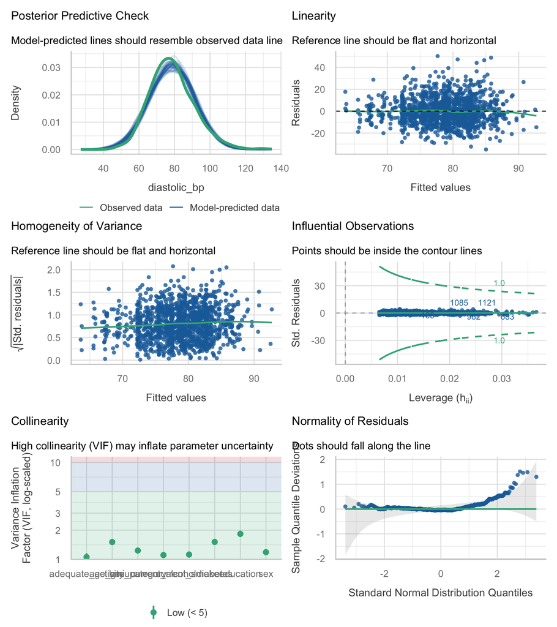

**Table 4. HC3 heteroscedasticity-consistent standard errors.**

| Term | Estimate | SE (OLS) | SE (HC3) | 95% CI (HC3) | p (HC3) |
| --- | --- | --- | --- | --- | --- |
| age_group18-25 | -5.05 | 1.391 | 1.243 | -7.49 to -2.62 | 0.000 |
| age_group36-45 | 1.30 | 1.009 | 1.002 | -0.67 to 3.26 | 0.196 |
| age_group46-55 | 5.30 | 1.043 | 1.034 | 3.27 to 7.33 | 0.000 |
| age_group56-65 | 4.35 | 1.098 | 1.104 | 2.18 to 6.51 | 0.000 |
| age_group>65 | 1.26 | 1.175 | 1.134 | -0.96 to 3.49 | 0.265 |
| sexMale | 1.94 | 0.692 | 0.696 | 0.57 to 3.30 | 0.005 |
| educationPrimary | 4.33 | 1.297 | 1.378 | 1.63 to 7.03 | 0.002 |
| educationSecondary | 0.64 | 1.269 | 1.291 | -1.90 to 3.17 | 0.622 |
| educationTertiary | 0.35 | 1.261 | 1.235 | -2.08 to 2.77 | 0.779 |
| bmi_categoryUnderweight | -3.71 | 1.442 | 1.508 | -6.67 to -0.75 | 0.014 |
| bmi_categoryOverweight | 3.14 | 0.773 | 0.796 | 1.58 to 4.70 | 0.000 |
| bmi_categoryObese | 5.11 | 0.885 | 0.870 | 3.40 to 6.81 | 0.000 |
| current_smokerYes | 0.69 | 1.364 | 1.658 | -2.56 to 3.95 | 0.676 |
| current_alcoholYes | 3.29 | 1.210 | 1.356 | 0.63 to 5.95 | 0.015 |
| adequate_activityYes | 0.14 | 0.655 | 0.663 | -1.16 to 1.44 | 0.836 |
| diabetesyes | -0.48 | 0.974 | 0.905 | -2.26 to 1.29 | 0.595 |
| diabetesunknown | 3.98 | 0.984 | 1.091 | 1.84 to 6.12 | 0.000 |

Because non-constant variance was detected, Table 4 reports HC3 robust standard errors. Point estimates are unchanged; only the uncertainty is re-estimated. The HC3 standard errors differ from the OLS ones by at most 22%, and no coefficient changes its significance status under robust inference. The substantive conclusions - obesity, sex, alcohol and mid-life age in; diabetes, smoking and activity out - do not depend on the variance assumption.

## Sensitivity analysis: prior diagnosis and treatment

Participants reporting a previous hypertension diagnosis average 83.9 mmHg diastolic against 76.7 mmHg in those who do not, and adding `prior_htn_diagnosis` to the model gives an adjusted difference of 5.9 mmHg (95% CI 4.4 to 7.4, p < 0.001), raising R-squared to 0.168. **This coefficient is not an effect of diagnosis on blood pressure.** The relationship is bidirectional: a diagnosis happens *because* pressure was high (pushing the coefficient up) and leads to antihypertensive treatment that lowers measured pressure (pushing it down). The file has **no medication variable**, so the two directions cannot be separated. The variable is therefore excluded from the main model and reported here only as a sensitivity analysis.

# Discussion

In this Kenyan outpatient sample, BMI category, sex, mid-life age and current alcohol use are independently associated with diastolic blood pressure. Adjusted for the other seven predictors, obese participants average 5.11 mmHg (95% CI 3.37 to 6.84) above healthy-weight participants, current drinkers 3.29 mmHg (95% CI 0.92 to 5.66) above non-drinkers, and men 1.94 mmHg (95% CI 0.58 to 3.30) above women. The age relationship is an inverted U: pressure peaks in the 46-55 band (5.30 mmHg (95% CI 3.25 to 7.34) above 26-35) and is essentially back to the reference level by 65, so - unlike systolic pressure - diastolic pressure does not identify the oldest attenders as highest risk. The crude diabetes association disappears completely on adjustment. Practically, diastolic pressure is the wrong screening quantity for older adults in this setting, and body size is the modifiable characteristic most strongly tied to it.

**Limitations.** This is a **facility-based convenience sample** of outpatient attenders, not a community sample, and is far better educated and more female than the Kenyan adult population, so no mean here generalises. The design is **cross-sectional**; nothing establishes temporality. **No predictor is continuous** - age is banded and BMI is only a WHO category - so residual confounding within band is guaranteed and no per-unit effect exists. **Antihypertensive medication is not recorded**, the most serious unmeasured confounder here: treated participants have lower measured pressure precisely because their underlying risk is higher, which biases the age, obesity and diabetes coefficients toward the null. Participants come from **three facilities with no facility identifier**, so the clustering of attenders within a facility cannot be modelled and the standard errors, robust or not, are probably too small. Complete-case analysis dropped 68 rows, and `monthly_income` was excluded because including it would have cost a further 408 rows, so household economic position is unadjusted for. Alcohol is recorded only as a yes/no, with no quantity or frequency, so the alcohol coefficient is a very crude exposure contrast built on 114 drinkers. Sodium intake, family history and kidney function are absent. Only 13% of the variance is explained.

**Future work.** Refit with continuous age, measured BMI, quantity-based alcohol exposure and a medication variable, and use a facility identifier to account for clustering - none of which this extract carries.

# Feasibility notes

*NOT part of a student report.*

- **Workable, but the weaker of the two blood-pressure outcomes.** Same 1376 complete cases and the same predictor set as `systolic_bp`, but the model explains 13.3% of variance against about 18% for systolic pressure, because the age relationship is non-monotonic.
- **The inverted-U age pattern is the interesting feature and the main trap.** Diastolic pressure peaks at 46-55 and falls in the over-65s. Students who assume “older = higher” will misreport the age coefficients, and anyone who models age as a linear term (if they recode the bands to numbers) will find almost nothing. As banded factors it works, which is a lucky accident of how the file was coded.
- **FATAL trap: `hypertension` must never be a predictor.** It is defined from the measured pressures, so it is a coarsened function of this outcome. `systolic_bp` must also stay out (r = 0.71 and a co-outcome). A model with either produces a big R-squared and answers nothing.
- **Missing-data teaching case.** `monthly_income` is 31.4% missing; adding it cuts the sample from 1376 to 968 and contributes nothing (p = 0.157). Here it also visibly destabilises the alcohol coefficient (3.29 to 4.43 mmHg), which makes the point better than the systolic version does.
- **Heteroscedasticity flagged (p < 0.001)**; HC3 changes nothing substantive (no significance flips). Good, genuine practice material.
- **`current_smoker` is sparse** (93 smokers in the file, almost all male) and **`bmi_category` “Underweight” is thin** (80 in the analytic sample). Keep both to one contrast each; no interactions.
- **Substantially redundant with `systolic_bp`.** Same predictors, same sample, largely the same story. A student should do one of the two, not both; systolic is the better choice unless the inverted-U age pattern is the point of the project.
- **Clustering cannot be modelled** (three facilities, no facility ID). No separation, no collinearity (max VIF 1.83), no influential points.